# Goal Seek

**Goal Seek functionality** lets the user perform **target optimization** to achieve the minimum possible budget for the desired target. It displays the output of target optimization process comparing budget and target allocation across various dimensions which took part in optimization.

## Input for Goal Seek Functionality

[figure not shown]

## Results from Goal Seek Functionality

#### Summary Metrics and CPA/ROI Chart

- **Summary Metrics** table containing results of the optimization at a high level:
  - **Total Budget:** It is the aggregated budget recommended by the optimizer for the entered target.
  - **Target:** It is the overall target for optimization entered by the user.
  - **CPA or ROI:** It is the CPA or ROI for the optimization plan based on the target type selection.
  - **Confidence Score:** It is the precision score for optimization calculated based on each dimension's response curve accuracy (computed through SMAPE i.e. 1-SMAPE) and optimized budget allocation%.
- **Chart comparing CPA or ROI** (based on the target type selection) is for median/mean (based on user selection) historic spend and optimization plan.

[figure not shown]

#### Optimization Plan

- This includes the target allocated to each dimension and their respective budget.
- The result includes budget and target at per day and for n number of days as selected by the user in the input panel.
- Median/mean (based on user selection) budget based on historic data is also displayed for users to compare budget allocation.
- Percentage allocation for total historic budget, median/mean (based on user selection) historic budget, optimized budget, and the target both at optimized and median/mean historic budget level is also displayed to understand their distribution across dimensions.
- If the budget for discarded dimension (if any) is included, then their median/mean (based on user selection) and budget entered by the user for these respective dimensions are also displayed as part of the output. Their budget percentage allocation (total, median/mean and budget entered by the user) is also included in the result. As these dimensions are discarded there will be no information on their target allocation.
- Following is the list of variables included in the result for the optimization plan:
  - **Original Median Budget/Day:** Median budget based on historic data per day
  - **Recommended Budget/Day:** Budget allocation to each dimension by the optimizer per day
  - **Original Total Budget Allocation %:** Percentage allocation for total budget for each dimension based on historic spend data
  - **Original Median/Mean Budget Allocation %:** Percentage allocation for median/mean (based on user selection) budget for each dimension based on historic spend data
  - **Recommended Budget Allocation %:** Percentage allocation for optimized budget for each dimension
  - **Recommended Total Budget Allocation:** Budget allocation to each dimension by the optimizer for n number of days
  - **Target/Day:** Target for each dimension based on budget allocation by the optimizer per day
  - **Overall Target:** Target for each dimension based on budget allocation by the optimizer for n days
  - **% of Target:** Percentage allocation for the target for each dimension
  - **Target at Original Median/Mean Budget Allocation %:** Target for each dimension based on the Original Median/Mean Budget Allocation %. For calculation overall recommended budget is considered and then dimension level allocation is calculated using Original Median/Mean Budget Allocation %. Finally, based on the dimension level budget their respective target is computed

[figure not shown]

#### Charts comparing the percentage distribution for Budget and Target Allocation

- Charts compare the percentage distribution of budget and target allocation for different dimensions.
- **Budget Allocation Chart** compares:
  - **Original Median/Mean Budget Allocation %:** Percentage allocation for median/mean (based on user selection) budget for each dimension based on historic spend data
  - **Recommended Budget Allocation %:** Percentage allocation for optimized budget for each dimension
- **Target Projection Chart** compares:
  - **% of Target:** Percentage allocation for the target for each dimension
  - **% of Target at Original Median/Mean Budget Allocation %:** Percentage allocation for the target for each dimension based on the Original Median/Mean Budget Allocation %

[figure not shown]

#### *Note on results from Goal Seek Functionality*

- *'Initial Plan', 'Target at Original Median/Mean Budget Allocation %' and 'Target Allocation Original' available under 'CPA/ROI comparison chart', 'Optimization Plan' and 'Target Projections chart' respectively are based on the historic median or mean (based on user selection) spend distribution, so no constraint given by the user for optimization applies to them. Due to this 'Initial Plan' and 'Target at Original Median/Mean Budget Allocation %' could be lower and greater respectively than the recommendation in a few cases.*
- *The user can download the optimization plan and configurations used for optimization in the optimize tab.*
  - *The optimization plan download option is available towards the end on the goal seek page.*
  - *Configuration download option is available below the submit button on the left panel on the goal seek page.*

#### *Note on discarding the dimension(s) to get optimum result in Goal Seek Functionality*

- *For some dimensions flat response curves will be displayed in the visualization on Predict tab. This is due to a bad fit to the data which is leading to flat curves.*
- *The flat curves when used in the Goal Seek functionality tend to result in suboptimal outputs.*
- *The recommendation is to either discard these curves during the visual inspection, unselect these dimensions in the input panel on goal seek tab or enter the minimum budget possible for these dimensions in the input panel on goal seek tab.*

### Backend Logic

- **Target:** This is the target entered by the user in the front end in the left-hand panel. This target is for n number of days (for non-seasonality) and date range (for seasonality) as selected by the user.
- **Target per day:** The total target is divided by n number of days as optimization run for per day target only and later computed for the total number of days. In the case of non-seasonality, the number of days is entered by the user, and in seasonality, the number of days is calculated based on the date range.
- **Model Equation Used:** Equation to capture the nonlinear response to media variable on the dependent variable using S Curve (Hill). In optimizer, this equation is utilized to get the corresponding conversions for a dimension based on its parameters and investment.
  - **Equation for Non-Seasonal Model:** c * X^a / ( X^a + b^a )
  - **Equation for Seasonal Model:** *( c * X^a / ( X^a + b^a ) )* *+ week_coeff + month_coeff*
  - **Model parameters and their bounds:**
    - **X:** Level of Exposure (Investment/Impression)
    - **a:** Shape parameter
    - **b:** Inflection parameter
    - **c:** Max/Saturation parameter
    - **week_coeff:** Weekly seasonality parameter, for each day of the week (only applicable for the model with seasonality)
    - **month_coeff:** Annual seasonality parameter, for each month of the year (only applicable for the model with seasonality)
- **Optimization Process:** Optimization works based on the incremental budget technique, comparing across different dimensions and then allocating it to the dimension which produces the highest number of targets or conversions in that iteration. The same process happens for multiple iterations till required target entered by the user is reached. Targets or conversions for a particular dimension are computed based on its response curve. Below is the step-by-step process followed for optimization:
  - **Filter for Selected Dimensions:** Only dimensions selected in the front end in the input panel are filtered for the optimization process.
  - **Maximum Bounds Check:** All the dimensions are checked for the target at maximum bounds. If the maximum target for a particular dimension can be achieved at a lower budget than the maximum bound then the maximum bound for that dimension is adjusted. This is done to provide budget capping to such dimensions.
  - **Incremental Budget Calculation:** Incremental budget for each iteration is calculated for the optimization process. 50% of the median or mean (based on user selection) budget of the dimension having the minimum value is considered as the incremental budget.
  - **Inital Budget and Target Allocation:** In cases where the minimum bound for dimensions entered by the user is not zero, the initial budget and respective target are allocated to these dimensions before the optimization process. This process is performed to make sure that minimum bounds entered by the user are allocated.
  - **Incremental Target Allocation:** Incremental process take place here while allocating the target and respective budget for optimization. Each dimension is allocated an incremental budget, and their respective target obtained is compared. The dimension with the highest target among all the dimensions is allocated the incremental budget and corresponding target. This process continues for several iterations until the target entered by the user for optimization is achieved.
  - **Note:**
    - *While allocating the target at each iteration, dimension level bounds are taken into consideration and the budget allocation is restricted within the bounds/constraints.*
    - *In case of impressions, response curves are computed based on impressions and target. And, the optimization process takes place based on the same instead of response curve based on investment and target.*
- **Confidence Score:** The score for optimization is calculated based on each dimension's response curve accuracy and optimized budget allocation% based on the following logic:
  - **Accuracy:** Calculating accuracy using the error metric for each dimension SMAPE (i.e. Accuracy = 1-SMAPE)
  - **Budget Allocated over Maximum:** The percentage recommended budget allocated over each dimension's maximum historic value
  - **Accuracy with Penalty Score:** Penalty factor of 20% is considered for budget allocation over each dimension's maximum historical spend. This penalty is applied by multiplying this factor with Budget Allocated over Maximum% and then subtracting it from the Accuracy.
  - **Confidence Score:** The final confidence score is then calculated by the weighted average of the adjusted Accuracy using Optimized Budget Allocation%.
- **Result:** Optimize budget and target for respective dimensions are obtained from the optimization process and then transformations are performed. Here, discarded dimensions are included in the optimization plan and the budget entered by the user in the front end to these dimensions is allocated. Various other variables mentioned under **Results from Goal Seek Functionality** section for summary metrics, optimization plan and charts are calculated.
  - **Assumption:**
    - *Target is evenly distributed across each day for the selected number of days.*

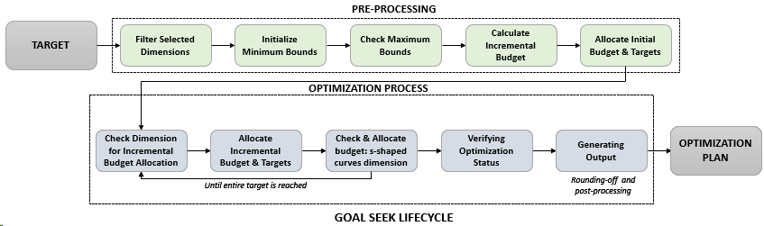